# Quizz 7: Binomial

Back to Index

## Coin Flip

**For Questions 1-5, consider the example of flipping a coin with unknown probability of heads ($\theta$):**

Suppose we use a Bernoulli likelihood for each coin flip, i.e., $f(y_i \mid \theta) = \theta^{y_i} (1-\theta)^{1-y_i} I_{\{ 0 \le \theta \le 1 \}}$ or $y_i = 1$, and a uniform prior for $\theta$.

### Question 1

What is the posterior distribution for $\theta$ if we observe the following sequence: (T, T, T, T) where H denotes heads ($Y=1$) and T denotes tails ($Y=0$)?

The posterior is $\text{Beta}(1+\sum y_i, 1 + n - \sum y_i)$ where $\sum y_i = 0$ and $n=4$

```r
n = 4
heads = 0          # successes
tails = n - heads  # fails

# prior
a = 1
b = 1
# posterior
a.pos = a + heads
b.pos = b + tails
cat('a.pos =', a.pos, 'b.pos =', b.pos)
```

```
## a.pos = 1 b.pos = 5
```

### Question 2

Which of the following graphs depicts the posterior PDF of $\theta$ if we observe the sequence (T, T, T, T)?

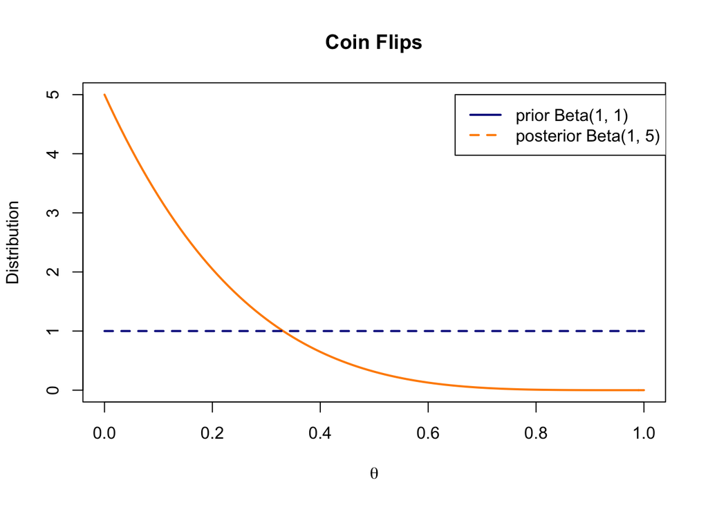

```r
theta = seq(from=0, to=1, by=.01)
plot(theta, dbeta(theta, a.pos, b.pos), type='l', lty=1, lwd=2, col='darkorange',
     xlab = expression(theta), ylab = "Distribution",)
lines(theta, dbeta(theta, a, b), lty=2, lwd=2, col='darkblue')
title("Coin Flips")
legend(0.65, 5, legend = c("prior Beta(1, 1)", "posterior Beta(1, 5)"), col=c("darkblue", "darkorange"), lty=c(1, 2), lwd=2)
```

### Question 3

What is the maximum likelihood estimate (MLE) of $\theta$ if we observe the sequence (T, T, T, T)?

- $MLE_{\theta} = \sum y_i / n = 0$

What is the posterior mean estimate of $\theta$ if we observe the sequence (T, T, T, T)? Round your answer to two decimal places.

- $E[\theta \mid \{T, T, T,T\} ] = \frac{\alpha + \sum y_i}{\alpha + \beta + n}$

```r
a = 1
b = 5
sum_y = 0
n = 4

(a.pos + sum_y)/(a.pos + b.pos + n)
```

```
## [1] 0.1
```

### Question 5

Use R or Excel to find the posterior probability that $\theta < 0.5$ if we observe the sequence (T,T,T,T). Round your answer to two decimal places.

```r
round(pbeta(0.5, a.pos, b.pos), 2)
```

```
## [1] 0.97
```

## Chemical refinement

**For Questions 6-9, consider the following scenario:**

### Question 6

What is the posterior distribution for $\theta$?

- Prior $\theta \sim \text{Beta}(2, 2)$
- Posterior $\theta \mid X \sim \text{Beta}(\alpha + \sum X_i, \beta + n - \sum X_i)$

Then:

- $n=20$
- $X$ = number of samples that fails = $6$
- $\theta \mid X \sim \text{Beta}(8, 16)$

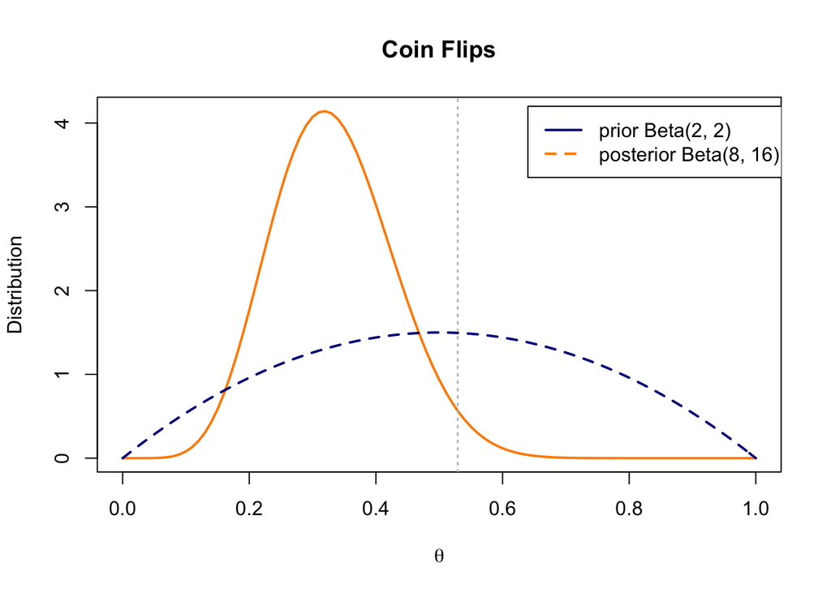

```r
theta = seq(from=0, to=1, by=.01)
plot(theta, dbeta(theta, 8, 16), type='l', lty=1, lwd=2, col='darkorange',
    main="Coin Flips",  xlab = expression(theta), ylab = "Distribution",)
lines(theta, dbeta(theta, 2, 2), lty=2, lwd=2, col='darkblue')
legend(0.64, 4.2, legend = c("prior Beta(2, 2)", "posterior Beta(8, 16)"), col=c("darkblue", "darkorange"), lty=c(1, 2), lwd=2)
abline(v=qbeta(.975, 8, 16), col="grey", lty=3, lwd=1.5) # Q.975
```

### Question 7

Use R or Excel to calculate the upper end of an equal-tailed 95% credible interval for $\theta$. Round your answer to two decimal places.

```r
round(qbeta(.975, 8, 16), 2)
```

```
## [1] 0.53
```

### Question 8

The engineer tells you that the process is considered promising and can proceed to another phase of testing if we are 90% sure that the failure rate is less than $.35$.

Calculate the posterior probability $P(\theta < .35 \mid x)$. In your role as the statistician, would you say that this new chemical should pass?

- Yes, $P(\theta < .35 \mid x) \ge 0.9$
- No, $P(\theta < .35 \mid x) < 0.9$. **[x]**

```r
round(pbeta(.35, 8, 16), 2)
```

```
## [1] 0.59
```

### Question 9

It is discovered that the budget will allow five more samples to be tested. These tests are conducted and none of them fail.

Calculate the new posterior probability $P(\theta < .35 \mid x_1, x_2)$. In your role as the statistician, would you say that this new chemical should pass (with the same requirement as in the previous question)? Hint: You can use the posterior from the previous analysis as the prior for this analysis. Assuming independence of tests, this yields the same posterior as the analysis in which we begin with the $\text{Beta}(2,2)$ prior and use all 25 tests as the data.

=> Update $\alpha = 8$, $\beta = 21$

- Yes, $P(\theta < .35 \mid x_1, x_2) \ge 0.9$.
- No, $P(\theta < .35 \mid x_1, x_2) < 0.9$ **[x]**

```r
pbeta(.35, 8, 21)
```

```
## [1] 0.8179064
```

### Question 10

Let $X \mid \theta \sim \text{Binomial}(9, \theta)$ and assume a $\text{Beta}(\alpha, \beta)$ prior for $\theta$. Suppose your prior guess (prior expectation) for $\theta$ is **0.4** and you wish to use a **prior effective sample size of 5**, what values of $\alpha$ and $\beta$ should you use?

- prior mean $E[\theta] = \frac{\alpha}{\alpha + \beta} = 0.4$
- effective sample size $n_{eff} = \alpha + \beta = 5$

Then $\alpha = 2$, $\beta = 3$

Back to Index